# Projeto Multidisciplinar II

## Informações sobre a Pesquisa de Informações Básicas Municipais - MUNIC 2024

```
A Pesquisa de Informações Básicas Municipais - Munic é um levantamento pormenorizado de registros administrativos sobre a estrutura, a dinâmica e o funcionamento das instituições públicas municipais, em especial a prefeitura, compreendendo, também, diferentes aspectos das políticas públicas setoriais sob responsabilidade dessa esfera governamental.

Com o lançamento desta publicação, o IBGE apresenta os resultados da Munic 2024, cuja investigação contemplou questões relacionadas a recursos humanos; informática e comunicação; governança; habitação; transporte e mobilidade urbana; agropecuária; instrumentos de gestão migratória; **e, pela primeira vez, igualdade racial**, tema resultante de convênio institucional firmado com o Ministério da Igualdade Racial. **Sua inserção objetivou conhecer a estrutura pública disponível nas municipalidades para a gestão de política específica sobre essa matéria, sendo apurada, inclusive, a existência de canais para recebimento, registro e acompanhamento de denúncias de violação de direitos étnico-raciais.** Os resultados obtidos no levantamento estão agregados por classes de tamanho da população, Grandes Regiões e Unidades da Federação, enquanto as análises, vastamente ilustradas, evidenciam os aspectos mais relevantes de cada um dos temas examinados e traçam comparações com as estatísticas obtidas em inquéritos anteriores.

Em razão da magnitude histórica do evento climático ocorrido no Rio Grande do Sul, em abril de 2024, esta edição da Munic pesquisou também, em caráter excepcional, questões sobre as medidas e ações empreendidas durante esse episódio, bem como sobre o dimensionamento e a administração de seus impactos, posto que as consequências de tais desastres não apenas comprometem as infraestruturas urbana e rural das municipalidades atingidas, mas também afetam a sua economia, com repercussões diretas sobre a saúde e o bem-estar das populações locais.

O volume inclui notas técnicas com considerações metodológicas sobre a pesquisa, bem como um glossário com os conceitos considerados essenciais para a compreensão de seus resultados.

No portal do IBGE na Internet, estão disponíveis, além desta publicação, também a base de dados completa da Munic 2024 e as tabelas de resultados correspondentes ao Questionário Básico da pesquisa.

Essas estatísticas possibilitam identificar as carências existentes nos Municípios brasileiros, contribuindo, assim, para a democratização da gestão pública por meio da formulação e do aprimoramento de políticas diferenciadas para questões específicas de suas populações.
```

## Importando pacotes

```python
import pandas as pd
import numpy as np
import matplotlib.pyplot as plt
```

## Informações dos dados escolhidos para análise de dados

```
1. Ano da pesquisa: 2024
2. Tema: Igualdade racial
3. Cada linha da base representa um município dos 5570 registrados. Para cada município, observamos a estrutura política disponível para a gestão da política de direitos étnico-raciais.
4. Base baixada: https://view.officeapps.live.com/op/view.aspx?src=https%3A%2F%2Fftp.ibge.gov.br%2FPerfil_Municipios%2F2024%2FBase_de_Dados%2FBase_MUNIC_2024_20251107.xlsx&wdOrigin=BROWSELINK
5. Análise baseada na planilha: Igualdade racial
6. Variáveis escolhidas para análise:

    - CodMun -> Código do município
    - Sigla UF -> Unidade Federativa
    - Cod Uf -> Código da Unidade Federativa
    - Mun -> Nome do município
    - Faixa_populacao -> Faixa da quantidade de pessoas que residem no município
    - Regiao -> Nome da região do Brasil
    - MIGR01  -> Caracterização do órgão gestor
    - MIGR101 -> Programas/ações população negra
    - MIGR102 -> Programas/ações para Indígenas
    - MIGR103 -> Programas/ações para Povos e comunidades tradicionais de matriz africana ou povos de terreiros
    - MIGR104 -> Programas/ações para Quilombolas
    - MIGR105 -> Programas/ações para Povos ciganos
    - MIGR106 -> Programas/ações para Demais povos e comunidades tradicionais
    - MIGR107 -> Não executa programas/ações
```

## Transformação dos dados

```python
# Dados originais
df = pd.read_excel('Base_MUNIC_2024_20251107.xlsx', sheet_name='Igualdade racial')

valores_nulos = df.isnull().sum() / len(df) # Verifica se há valores nulos
duplicatas = df.duplicated().sum() # Verifica se há duplicatas

print(df.shape)
print(df.dtypes)
print("\nProporção de valores nulos por coluna:")
print(valores_nulos)
print(f"\nQuantidade de linhas duplicadas: {duplicatas}\n")
display(df.head())
```

```
(5570, 433)
CodMun       int64
Sigla UF    object
Cod Uf       int64
Mun         object
PopMun       int64
             ...
MIGR634     object
MIGR635     object
MIGR636     object
MIGR637     object
MIGR638     object
Length: 433, dtype: object

Proporção de valores nulos por coluna:
CodMun      0.0
Sigla UF    0.0
Cod Uf      0.0
Mun         0.0
PopMun      0.0
           ...
MIGR634     0.0
MIGR635     0.0
MIGR636     0.0
MIGR637     0.0
MIGR638     0.0
Length: 433, dtype: float64

Quantidade de linhas duplicadas: 0
```

|  | CodMun | Sigla UF | Cod Uf | Mun | PopMun | Faixa_populacao | Regiao | MIGR01 | MIGR021 | MIGR022 | ... | MIGR624 | MIGR625 | MIGR631 | MIGR632 | MIGR633 | MIGR634 | MIGR635 | MIGR636 | MIGR637 | MIGR638 |
| --- | --- | --- | --- | --- | --- | --- | --- | --- | --- | --- | --- | --- | --- | --- | --- | --- | --- | --- | --- | --- | --- |
| 0 | 1100015 | RO | 11 | Alta Floresta DOeste | 22853 | 4 - 20001 até 50000 | 1 - Norte | Não possui estrutura | - | - | ... | - | - | - | - | - | - | - | - | - | Sim |
| 1 | 1100023 | RO | 11 | Ariquemes | 108573 | 6 - 100001 até 500000 | 1 - Norte | Não possui estrutura | - | - | ... | Sim | - | Sim | Sim | Não | Não | Não | Não | Sim | - |
| 2 | 1100031 | RO | 11 | Cabixi | 5690 | 2 - 5001 até 10000 | 1 - Norte | Não possui estrutura | - | - | ... | Não | - | Não | Sim | Não | Não | Não | Não | Não | - |
| 3 | 1100049 | RO | 11 | Cacoal | 97637 | 5 - 50001 até 100000 | 1 - Norte | Não possui estrutura | - | - | ... | - | - | Sim | Sim | Não | Não | Não | Sim | Não | - |
| 4 | 1100056 | RO | 11 | Cerejeiras | 16975 | 3 - 10001 até 20000 | 1 - Norte | Não possui estrutura | - | - | ... | - | - | - | - | - | - | - | - | - | Sim |

5 rows × 433 columns

```python
# Realizando transformações + pré-análise
df['Municipio'] = df['CodMun'].astype('str') + ' - ' + df['Mun']
df['UF'] = df['Cod Uf'].astype('str') + ' - ' + df['Sigla UF']
df = df[['Regiao','UF','Municipio','Faixa_populacao','MIGR01', 'MIGR101','MIGR102','MIGR103','MIGR104','MIGR105', 'MIGR106','MIGR107']]

df = (df.rename(columns={
    'MIGR01':  'Caracterização do órgão gestor',
    'MIGR101': 'Programas/ações população negra',
    'MIGR102': 'Programas/ações para Indígenas',
    'MIGR103': 'Programas/ações para Povos e comunidades tradicionais de matriz africana ou povos de terreiros',
    'MIGR104': 'Programas/ações para Quilombolas',
    'MIGR105': 'Programas/ações para Povos ciganos',
    'MIGR106': 'Programas/ações para Demais povos e comunidades tradicionais',
    'MIGR107': 'Não executa programas/ações',
}).replace('-', np.nan))

print(df.shape)
print(df.dtypes)
display(df.head())

# Verificando se há mais de um registro do mesmo município
qtd_mun_unc = df[['UF','Municipio']].duplicated().sum() # Resultado 0
qtd_mun_unc
```

```
(5570, 12)
Regiao                                                                                            object
UF                                                                                                object
Municipio                                                                                         object
Faixa_populacao                                                                                   object
Caracterização do órgão gestor                                                                    object
Programas/ações população negra                                                                   object
Programas/ações para Indígenas                                                                    object
Programas/ações para Povos e comunidades tradicionais de matriz africana ou povos de terreiros    object
Programas/ações para Quilombolas                                                                  object
Programas/ações para Povos ciganos                                                                object
Programas/ações para Demais povos e comunidades tradicionais                                      object
Não executa programas/ações                                                                       object
dtype: object
```

|  | Regiao | UF | Municipio | Faixa_populacao | Caracterização do órgão gestor | Programas/ações população negra | Programas/ações para Indígenas | Programas/ações para Povos e comunidades tradicionais de matriz africana ou povos de terreiros | Programas/ações para Quilombolas | Programas/ações para Povos ciganos | Programas/ações para Demais povos e comunidades tradicionais | Não executa programas/ações |
| --- | --- | --- | --- | --- | --- | --- | --- | --- | --- | --- | --- | --- |
| 0 | 1 - Norte | 11 - RO | 1100015 - Alta Floresta DOeste | 4 - 20001 até 50000 | Não possui estrutura | NaN | NaN | NaN | NaN | NaN | NaN | NaN |
| 1 | 1 - Norte | 11 - RO | 1100023 - Ariquemes | 6 - 100001 até 500000 | Não possui estrutura | NaN | NaN | NaN | NaN | NaN | NaN | NaN |
| 2 | 1 - Norte | 11 - RO | 1100031 - Cabixi | 2 - 5001 até 10000 | Não possui estrutura | NaN | NaN | NaN | NaN | NaN | NaN | NaN |
| 3 | 1 - Norte | 11 - RO | 1100049 - Cacoal | 5 - 50001 até 100000 | Não possui estrutura | NaN | NaN | NaN | NaN | NaN | NaN | NaN |
| 4 | 1 - Norte | 11 - RO | 1100056 - Cerejeiras | 3 - 10001 até 20000 | Não possui estrutura | NaN | NaN | NaN | NaN | NaN | NaN | NaN |

```
0
```

## Sumarização dos dados

```
Principais achados dos 5570 municípios registrados:

1. 75,7% não possuem estrutura declarada e, por isso, não avançaram para o bloco de detalhamento de programas e ações. Aproximadamente 74,73% (3153 municípios de 4219) desses municípios não estruturados, possuem uma população de até 20 mil habitantes.
2. 0,23% não informaram a caracterização do órgão gestor
3. 0,12% declararam como 'Recusa'
4. Apenas 23,9% (1331) dos municípios tiveram suas estruturas declaradas.
   - Programas/ações população negra: 895
   - Programas/ações para Quilombolas: 549
   - Programas/ações para Povos e comunidades tradicionais de matriz africana ou povos de terreiros: 544
   - Programas/ações para Demais povos e comunidades tradicionais: 501
   - Programas/ações para Indígenas: 379
   - Não executa programas/ações: 270
   - Programas/ações para Povos ciganos: 186
   - A maior concentração dos municípios estruturados (45%), possuem uma população que vai de 10 mil habitantes até 50 mil habitantes.
```

### 1. Frequência da Caracterização do gestor responsável

```python
# Calculando a frequência da Caracterização do gestor nos 5570 municípios registrados.
def tabela_frequencia(var):

    frequencia_relativa = var.value_counts()/len(var)

    return pd.DataFrame({
        'Freq. absoluta': var.value_counts(),
        'Freq. relativa': frequencia_relativa,
        'Freq. relativa %': frequencia_relativa * 100

    })

display(tabela_frequencia(df['Caracterização do órgão gestor']))
```

| Caracterização do órgão gestor | Freq. absoluta | Freq. relativa | Freq. relativa % |
| --- | --- | --- | --- |
| Não possui estrutura | 4219 | 0.757451 | 75.745063 |
| Setor subordinado a outra secretaria | 1183 | 0.212388 | 21.238779 |
| Secretaria municipal em conjunto com outras políticas setoriais | 61 | 0.010952 | 1.095153 |
| Setor subordinado diretamente à chefia do Executivo | 48 | 0.008618 | 0.861759 |
| Secretaria municipal exclusiva | 34 | 0.006104 | 0.610413 |
| Não informou | 13 | 0.002334 | 0.233393 |
| Recusa | 7 | 0.001257 | 0.125673 |
| Órgão da administração indireta | 5 | 0.000898 | 0.089767 |

#### Órgão gestor sem estrutura para promover igualdade racial

```python
# Filtrando municípios sem estrutura
sem_estrutura = df[df['Caracterização do órgão gestor'] == 'Não possui estrutura']

# Conferindo se há ações realizadas mesmo em municípios sem estrutura
# Municípios que não possuem estruturas declaradas, não prosseguiram para o bloco de detalhamento da realização das ações
programas = [
    'Programas/ações população negra',
    'Programas/ações para Indígenas',
    'Programas/ações para Povos e comunidades tradicionais de matriz africana ou povos de terreiros',
    'Programas/ações para Quilombolas',
    'Programas/ações para Povos ciganos',
    'Programas/ações para Demais povos e comunidades tradicionais',
    'Não executa programas/ações',
]

sem_estrutura[programas].count()
```

```
Programas/ações população negra                                                                   0
Programas/ações para Indígenas                                                                    0
Programas/ações para Povos e comunidades tradicionais de matriz africana ou povos de terreiros    0
Programas/ações para Quilombolas                                                                  0
Programas/ações para Povos ciganos                                                                0
Programas/ações para Demais povos e comunidades tradicionais                                      0
Não executa programas/ações                                                                       0
dtype: int64
```

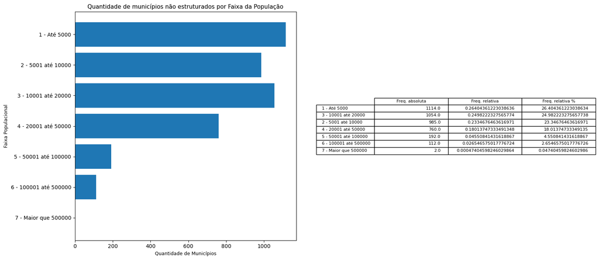

```python
# Analisando uma possível relação entre Caracterização do órgão do gestor e a Faixa da população.
pop = sem_estrutura.groupby('Faixa_populacao')['Faixa_populacao'].count().sort_index(ascending=False)
dfpop = pd.DataFrame(pop)
valores = dfpop['Faixa_populacao']

# Visualização
fig, (ax1, ax2) = plt.subplots(1, 2, figsize=(16,7))

ax1.set_title('Quantidade de municípios não estruturados por Faixa da População', fontsize=11)
ax1.barh(valores.index, valores)
ax1.set_xlabel('Quantidade de Municípios', fontsize=9)
ax1.set_ylabel('Faixa Populacional', fontsize=9)


ax2.axis('off')
ax2.table(cellText=tabela_frequencia(sem_estrutura['Faixa_populacao']).values,
          colLabels=tabela_frequencia(sem_estrutura['Faixa_populacao']).columns,
          rowLabels = tabela_frequencia(sem_estrutura['Faixa_populacao']).index,
          loc='center')

plt.tight_layout()
plt.show()
```

#### Órgão gestor com estrutura para promover igualdade racial

Não contabilizando os classificados como: 'Não possui estrutura', 'Não informou' e 'Recusa'.

```python
com_estrutura = df[
    (df['Caracterização do órgão gestor'] != 'Não possui estrutura') &
    (df['Caracterização do órgão gestor'] != 'Não informou') &
    (df['Caracterização do órgão gestor'] != 'Recusa')
]

# Conta a quantidade de registros para cada variável de programas. Os NaN não são contados
com_estrutura[programas].count()
```

```
Programas/ações população negra                                                                   1061
Programas/ações para Indígenas                                                                    1061
Programas/ações para Povos e comunidades tradicionais de matriz africana ou povos de terreiros    1061
Programas/ações para Quilombolas                                                                  1061
Programas/ações para Povos ciganos                                                                1061
Programas/ações para Demais povos e comunidades tradicionais                                      1061
Não executa programas/ações                                                                        270
dtype: int64
```

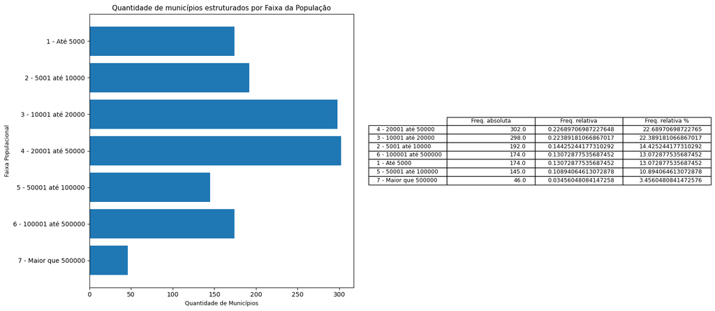

```python
# Analisando uma possível relação entre Caracterização do órgão do gestor e a Faixa da população.
pop = com_estrutura.groupby('Faixa_populacao')['Faixa_populacao'].count().sort_index(ascending=False)
dfpop = pd.DataFrame(pop)
valores = dfpop['Faixa_populacao']

# Visualização
fig, (ax1, ax2) = plt.subplots(1, 2, figsize=(16,7))

ax1.set_title('Quantidade de municípios estruturados por Faixa da População', fontsize=11)
ax1.barh(valores.index, valores)
ax1.set_xlabel('Quantidade de Municípios', fontsize=9)
ax1.set_ylabel('Faixa Populacional', fontsize=9)

ax2.axis('off')
ax2.table(cellText=tabela_frequencia(com_estrutura['Faixa_populacao']).values,
          colLabels=tabela_frequencia(com_estrutura['Faixa_populacao']).columns,
          rowLabels=tabela_frequencia(com_estrutura['Faixa_populacao']).index,
          loc='center')

plt.tight_layout()
plt.show()
```

```python
# Conta quantas vezes cada município realizou uma ação para cada etnia

municipio_count = com_estrutura.groupby(['Regiao','UF','Municipio'], observed=True, as_index=False).agg(
    {
        'Programas/ações população negra': lambda x: (x == 'Sim').sum(),
        'Programas/ações para Indígenas': lambda x: (x == 'Sim').sum(),
        'Programas/ações para Povos e comunidades tradicionais de matriz africana ou povos de terreiros': lambda x: (x == 'Sim').sum(),
        'Programas/ações para Quilombolas': lambda x: (x == 'Sim').sum(),
        'Programas/ações para Povos ciganos': lambda x: (x == 'Sim').sum(),
        'Programas/ações para Demais povos e comunidades tradicionais': lambda x: (x == 'Sim').sum(),
        'Não executa programas/ações': lambda x: (x == 'Sim').sum()
    }
)
municipio_count.head()
```

|  | Regiao | UF | Municipio | Programas/ações população negra | Programas/ações para Indígenas | Programas/ações para Povos e comunidades tradicionais de matriz africana ou povos de terreiros | Programas/ações para Quilombolas | Programas/ações para Povos ciganos | Programas/ações para Demais povos e comunidades tradicionais | Não executa programas/ações |
| --- | --- | --- | --- | --- | --- | --- | --- | --- | --- | --- |
| 0 | 1 - Norte | 11 - RO | 1100098 - Espigão DOeste | 0 | 1 | 0 | 0 | 0 | 1 | 0 |
| 1 | 1 - Norte | 11 - RO | 1100155 - Ouro Preto do Oeste | 1 | 0 | 0 | 0 | 0 | 0 | 0 |
| 2 | 1 - Norte | 11 - RO | 1100189 - Pimenta Bueno | 0 | 1 | 0 | 0 | 0 | 0 | 0 |
| 3 | 1 - Norte | 11 - RO | 1100205 - Porto Velho | 1 | 0 | 0 | 0 | 0 | 0 | 0 |
| 4 | 1 - Norte | 11 - RO | 1100296 - Santa Luzia DOeste | 1 | 1 | 1 | 0 | 0 | 0 | 0 |

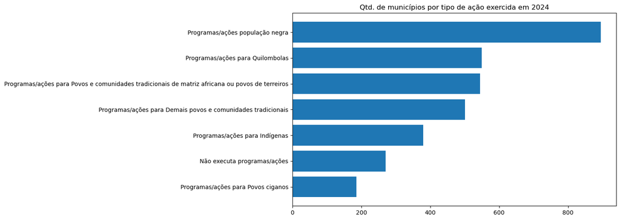

```
Programas/ações população negra                                                                   895
Programas/ações para Quilombolas                                                                  549
Programas/ações para Povos e comunidades tradicionais de matriz africana ou povos de terreiros    544
Programas/ações para Demais povos e comunidades tradicionais                                      501
Programas/ações para Indígenas                                                                    379
Não executa programas/ações                                                                       270
Programas/ações para Povos ciganos                                                                186
dtype: int64
```

```python
# Gráfico que mostra qual tipo de ação realizada possui mais registros
categorias = [
    'Programas/ações população negra',
    'Programas/ações para Indígenas',
    'Programas/ações para Povos e comunidades tradicionais de matriz africana ou povos de terreiros',
    'Programas/ações para Quilombolas',
    'Programas/ações para Povos ciganos',
    'Programas/ações para Demais povos e comunidades tradicionais',
    'Não executa programas/ações',
]

valores = municipio_count[categorias].sum().sort_values()

plt.figure(figsize = (10,6))
plt.barh(valores.index, valores)
plt.title('Qtd. de municípios por tipo de ação exercida em 2024')
plt.show()

valores.sort_values(ascending=False)
```

### 2. Municípios estruturados que em 2024 tiveram ações registradas para as pessoas de todos os grupos étnico-raciais

1. Total: **72 municípios**
2. Municípios com seus respectivos códigos de identificação: ['1100601 - Cacaulândia', '1303205 - Novo Airão', '1503101 - Gurupá', '1600303 - Macapá', '1700301 - Aguiarnópolis', '2100303 - Aldeias Altas', '2103703 - Cururupu', '2103752 - Davinópolis', '2112803 - Viana', '2208403 - Piripiri', '2302503 - Brejo Santo', '2305357 - Icapuí', '2308609 - Monsenhor Tabosa', '2309805 - Pacoti', '2310209 - Paracuru', '2313252 - Tarrafas', '2412005 - São Gonçalo do Amarante', '2412559 - São Miguel do Gostoso', '2501807 - Bayeux', '2601201 - Arcoverde', '2604106 - Caruaru', '2610707 - Paulista', '2613008 - São Bento do Una', '2613909 - Serra Talhada', '2706703 - Penedo', '2707503 - Porto Real do Colégio', '2900801 - Alcobaça', '2904902 - Cachoeira', '2905701 - Camaçari', '2907301 - Castro Alves', '2915809 - Itambé', '2918001 - Jequié', '2925303 - Porto Seguro', '2933307 - Vitória da Conquista', '3103504 - Araguari', '3104007 - Araxá', '3118601 - Contagem', '3120904 - Curvelo', '3122306 - Divinópolis', '3136702 - Juiz de Fora', '3143906 - Muriaé', '3144805 - Nova Lima', '3154606 - Ribeirão das Neves', '3170206 - Uberlândia', '3300100 - Angra dos Reis', '3300258 - Arraial do Cabo', '3303500 - Nova Iguaçu', '3303906 - Petrópolis', '3304409 - Rio Claro', '3506003 - Bauru', '3519907 - Iepê', '3523107 - Itaquaquecetuba', '3534401 - Osasco', '3543709 - Rincão', '3548500 - Santos', '3550308 - São Paulo', '4104907 - Castro', '4110706 - Irati', '4113700 - Londrina', '4119905 - Ponta Grossa', '4205407 - Florianópolis', '4313409 - Novo Hamburgo', '4315602 - Rio Grande', '4318705 - São Leopoldo', '4319109 - São Martinho', '4322376 - Unistalda', '4322533 - Vale do Sol', '5004908 - Jaraguari', '5006309 - Paranaíba', '5205802 - Corumbá de Goiás', '5220454 - Senador Canedo', '5300108 - Brasília']

```python
categorias2 = [
    'Programas/ações população negra',
    'Programas/ações para Indígenas',
    'Programas/ações para Povos e comunidades tradicionais de matriz africana ou povos de terreiros',
    'Programas/ações para Quilombolas',
    'Programas/ações para Povos ciganos',
    'Programas/ações para Demais povos e comunidades tradicionais'
]

municipio_maior_acoes = municipio_count[(municipio_count[categorias2] == 1).all(axis=1)]
print(f'Quantidade de municípios: {len(municipio_maior_acoes)}')

municipio_maior_acoes.head()
```

```
Quantidade de municípios: 72
```

|  | Regiao | UF | Municipio | Programas/ações população negra | Programas/ações para Indígenas | Programas/ações para Povos e comunidades tradicionais de matriz africana ou povos de terreiros | Programas/ações para Quilombolas | Programas/ações para Povos ciganos | Programas/ações para Demais povos e comunidades tradicionais | Não executa programas/ações |
| --- | --- | --- | --- | --- | --- | --- | --- | --- | --- | --- |
| 10 | 1 - Norte | 11 - RO | 1100601 - Cacaulândia | 1 | 1 | 1 | 1 | 1 | 1 | 0 |
| 41 | 1 - Norte | 13 - AM | 1303205 - Novo Airão | 1 | 1 | 1 | 1 | 1 | 1 | 0 |
| 72 | 1 - Norte | 15 - PA | 1503101 - Gurupá | 1 | 1 | 1 | 1 | 1 | 1 | 0 |
| 93 | 1 - Norte | 16 - AP | 1600303 - Macapá | 1 | 1 | 1 | 1 | 1 | 1 | 0 |
| 100 | 1 - Norte | 17 - TO | 1700301 - Aguiarnópolis | 1 | 1 | 1 | 1 | 1 | 1 | 0 |

```python
lista1_mun = list(municipio_maior_acoes['Municipio'])
```

### 3. Municípios estruturados que em 2024 não tiveram ações registradas para nenhum grupo étnico-racial

1. Total: **270 municípios**
2. Municípios com seus respectivos códigos de identificação: ['1100403 - Alto Paraíso', '1100502 - Novo Horizonte do Oeste', '1200013 - Acrelândia', '1200450 - Senador Guiomard', '1200807 - Porto Acre', '1301001 - Carauari', '1301605 - Fonte Boa', '1400282 - Iracema', '1508357 - Vitória do Xingu', '1600055 - Serra do Navio', '1600154 - Pedra Branca do Amapari', '1703909 - Caseara', '1705607 - Conceição do Tocantins', '1720937 - Taipas do Tocantins', '2100055 - Açailândia', '2100550 - Amapá do Maranhão', '2102507 - Cajari', '2102903 - Carutapera', '2104008 - Esperantinópolis', '2104305 - Godofredo Viana', '2104404 - Gonçalves Dias', '2104552 - Governador Edison Lobão', '2104677 - Governador Nunes Freire', '2105807 - Lago do Junco', '2105906 - Lago Verde', '2106326 - Maracaçumé', '2106805 - Mirinzal', '2107001 - Montes Altos', '2112001 - Tasso Fragoso', '2112233 - Trizidela do Vale', '2204659 - Ilha Grande', '2205524 - Júlio Borges', '2206654 - Morro Cabeça no Tempo', '2207108 - Olho DÁgua do Piauí', '2207355 - Pajeú do Piauí', '2207793 - Pau DArco do Piauí', '2211605 - Vila Nova do Piauí', '2300101 - Abaiara', '2300150 - Acarape', '2300606 - Altaneira', '2301109 - Aracati', '2301950 - Barreira', '2302909 - Capistrano', '2304608 - General Sampaio', '2304657 - Graça', '2305001 - Guaraciaba do Norte', '2308708 - Morada Nova', '2309003 - Mucambo', '2309706 - Pacatuba', '2312601 - São Luís do Curu', '2313351 - Tejuçuoca', '2401453 - Baraúna', '2404101 - Galinhos', '2404309 - Governador Dix-Sept Rosado', '2404853 - Itajá', '2406908 - Lucrécia', '2407609 - Messias Targino', '2407807 - Monte Alegre', '2409407 - Pau dos Ferros', '2412104 - São João do Sabugi', '2413607 - Severiano Melo', '2501005 - Araruna', '2501534 - Baraúna', '2503407 - Cacimba de Areia', '2504207 - Catingueira', '2504355 - Caturité', '2505279 - Curral de Cima', '2505352 - Damião', '2505907 - Emas', '2507804 - Junco do Seridó', '2509602 - Monte Horebe', '2514305 - São José de Caiana', '2514552 - São José de Princesa', '2514701 - São José do Sabugi', '2514909 - São Mamede', '2516102 - Soledade', '2517001 - Umbuzeiro', '2601300 - Barra de Guabiraba', '2601508 - Belém de Maria', '2603504 - Camocim de São Félix', '2604502 - Chã Grande', '2605202 - Escada', '2607109 - Ingazeira', '2607653 - Itambé', '2608602 - Lagoa do Ouro', '2611200 - Poção', '2611309 - Pombos', '2612406 - Sanharó', '2614006 - Serrita', '2614204 - Sirinhaém', '2702108 - Colônia Leopoldina', '2702801 - Flexeiras', '2703007 - Ibateguara', '2703502 - Jacuípe', '2804003 - Maruim', '2904704 - Buerarema', '2906709 - Cândido Sales', '2908101 - Cocos', '2908200 - Conceição da Feira', '2911204 - Gandu', '2911709 - Guanambi', '2916609 - Itapitanga', '2918209 - Jiquiriçá', '2920809 - Marcionílio Souza', '2920908 - Mascote', '2923209 - Oliveira dos Brejinhos', '2924652 - Pintadas', '2925501 - Prado', '2926004 - Remanso', '2926202 - Riachão das Neves', '3103900 - Araújos', '3109253 - Bugre', '3110707 - Cambuquira', '3113701 - Carlos Chagas', '3114550 - Carneirinho', '3115409 - Catas Altas da Noruega', '3120870 - Curral de Dentro', '3122355 - Divisa Alegre', '3123304 - Dores do Turvo', '3123700 - Engenheiro Caldas', '3127404 - Gonçalves', '3128907 - Guimarânia', '3129301 - Iapu', '3131604 - Iraí de Minas', '3132008 - Itacambira', '3132206 - Itaguara', '3133907 - Itaverava', '3134608 - Jaboticatubas', '3135902 - Jesuânia', '3136108 - Joanésia', '3137536 - Lagoa Grande', '3138302 - Leandro Ferreira', '3138807 - Luz', '3139706 - Maravilhas', '3145372 - Novorizonte', '3145505 - Olímpio Noronha', '3147907 - Passos', '3149200 - Pedrinópolis', '3155306 - Rio Manso', '3155603 - Rio Pardo de Minas', '3159803 - Santa Vitória', '3160009 - Santo Antônio do Aventureiro', '3160306 - Santo Antônio do Jacinto', '3161304 - São Francisco de Sales', '3163706 - São Lourenço', '3166204 - Senhora dos Remédios', '3167103 - Serro', '3170651 - Vargem Grande do Rio Pardo', '3200136 - Águia Branca', '3200805 - Baixo Guandu', '3201704 - Conceição do Castelo', '3203304 - Mantenópolis', '3203353 - Marilândia', '3203601 - Mucurici', '3204351 - Rio Bananal', '3204609 - Santa Teresa', '3301504 - Cordeiro', '3302809 - Mendes', '3303401 - Nova Friburgo', '3304110 - Porto Real', '3304706 - Santo Antônio de Pádua', '3500808 - Alfredo Marcondes', '3502903 - Araçoiaba da Serra', '3503802 - Artur Nogueira', '3505906 - Batatais', '3506706 - Boa Esperança do Sul', '3507209 - Borá', '3507407 - Borborema', '3509254 - Cajati', '3509304 - Cajobi', '3509601 - Campo Limpo Paulista', '3511409 - Cerqueira César', '3512506 - Coroados', '3515509 - Fernandópolis', '3519253 - Iaras', '3519600 - Ibitinga', '3520905 - Ipaussu', '3525201 - Jarinu', '3527207 - Lorena', '3537909 - Pilar do Sul', '3538303 - Piquerobi', '3544400 - Rubiácea', '3546207 - Santa Cruz da Conceição', '3549201 - São João das Duas Pontes', '3550506 - São Pedro do Turvo', '3551702 - Sertãozinho', '3552809 - Taboão da Serra', '3553658 - Taquaral', '3554201 - Tejupá', '3556305 - Valparaíso', '4100806 - Alvorada do Sul', '4103701 - Cambé', '4104451 - Cantagalo', '4107108 - Diamante do Norte', '4107520 - Esperança Nova', '4107553 - Farol', '4107900 - Floresta', '4110201 - Inácio Martins', '4110607 - Iporã', '4111001 - Itambaracá', '4111506 - Ivaiporã', '4111555 - Ivaté', '4111803 - Jacarezinho', '4116406 - Nossa Senhora das Graças', '4117222 - Nova Santa Rosa', '4122701 - Sabáudia', '4123006 - Salto do Lontra', '4123204 - Santa Cecília do Pavão', '4124400 - Santo Antônio do Sudoeste', '4126009 - São Sebastião da Amoreira', '4126108 - São Tomé', '4126272 - Saudade do Iguaçu', '4127700 - Toledo', '4128104 - Umuarama', '4128302 - Uniflor', '4128401 - Uraí', '4204004 - Catanduvas', '4205308 - Faxinal dos Guedes', '4207304 - Imbituba', '4213401 - Ponte Serrada', '4214003 - Presidente Getúlio', '4215687 - Santa Terezinha do Progresso', '4217253 - São Pedro de Alcântara', '4300406 - Alegrete', '4302105 - Bento Gonçalves', '4302402 - Bom Retiro do Sul', '4305132 - Cerro Branco', '4306932 - Entre-Ijuís', '4307203 - Erval Grande', '4309753 - Ibarama', '4310553 - Itacurubi', '4311130 - Jari', '4315149 - Presidente Lucena', '4318457 - São José das Missões', '4319000 - São Marcos', '4319364 - São Pedro das Missões', '4319752 - São Vendelino', '4322509 - Vacaria', '5002001 - Batayporã', '5002605 - Camapuã', '5006408 - Pedro Gomes', '5007406 - Rio Verde de Mato Grosso', '5100409 - Alto Garças', '5101209 - Araguainha', '5106182 - Nova Lacerda', '5107248 - Santa Carmem', '5107883 - Serra Nova Dourada', '5200852 - Americano do Brasil', '5201504 - Aporé', '5202809 - Avelinópolis', '5203104 - Baliza', '5203302 - Bela Vista de Goiás', '5203575 - Bonópolis', '5204003 - Cabeceiras', '5205000 - Carmo do Rio Verde', '5205406 - Ceres', '5206305 - Cristianópolis', '5208152 - Gameleira de Goiás', '5208608 - Goianésia', '5210307 - Israelândia', '5212055 - Jesúpolis', '5212303 - Leopoldo de Bulhões', '5215256 - Novo Planalto', '5215306 - Orizona', '5219506 - Santa Rosa de Goiás', '5219605 - Santa Tereza de Goiás', '5219738 - Santo Antônio de Goiás', '5219902 - São Francisco de Goiás', '5221403 - Trindade', '5222005 - Vianópolis']

```python
municipio_menor_acoes = municipio_count[(municipio_count[categorias2] == 0).all(axis=1) & (municipio_count['Não executa programas/ações'] == 1)]
print(f'Quantidade de municípios: {len(municipio_menor_acoes)}')
municipio_menor_acoes.head()
```

```
Quantidade de municípios: 270
```

|  | Regiao | UF | Municipio | Programas/ações população negra | Programas/ações para Indígenas | Programas/ações para Povos e comunidades tradicionais de matriz africana ou povos de terreiros | Programas/ações para Quilombolas | Programas/ações para Povos ciganos | Programas/ações para Demais povos e comunidades tradicionais | Não executa programas/ações |
| --- | --- | --- | --- | --- | --- | --- | --- | --- | --- | --- |
| 8 | 1 - Norte | 11 - RO | 1100403 - Alto Paraíso | 0 | 0 | 0 | 0 | 0 | 0 | 1 |
| 9 | 1 - Norte | 11 - RO | 1100502 - Novo Horizonte do Oeste | 0 | 0 | 0 | 0 | 0 | 0 | 1 |
| 14 | 1 - Norte | 12 - AC | 1200013 - Acrelândia | 0 | 0 | 0 | 0 | 0 | 0 | 1 |
| 29 | 1 - Norte | 12 - AC | 1200450 - Senador Guiomard | 0 | 0 | 0 | 0 | 0 | 0 | 1 |
| 31 | 1 - Norte | 12 - AC | 1200807 - Porto Acre | 0 | 0 | 0 | 0 | 0 | 0 | 1 |

```python
lista2_mun = list(municipio_menor_acoes['Municipio'])
```

## Perguntas a serem respondidas

1. Quais foram os dados que você utilizou e por qual motivo? Considerando a MUNIC. Especifique as transformações que você fez para cada variável e comente sobre o tratamento de dados que você fez, dizendo também qual a ferramenta usada para isso.
2. Qual foi o recorte geográfico que você utilizou e por qual motivo?
3. Se você tivesse que nomear o seu trabalho, qual nome daria? Por qual motivo?
4. Cite os 5 principais resultados que você encontrou e destaque o mais relevante

### Minha resposta:

```
1. Compreender, respeitar e analisar as pautas sociais é, inegavelmente, fundamental para o desenvolvimento da sociedade. Por ser a primeira vez que a MUNIC 2024 incluiu o tema Igualdade racial em sua pesquisa, tive interesse em explorar essa base de dados e compreender a situação de algumas variáveis relacionadas ao funcionamento das instituições públicas municipais. O objetivo deste trabalho é identificar quais municípios possuem estrutura declarada para promover a gestão de políticas específicas voltadas à igualdade racial, ou seja, programas e ações direcionados a esse tema. Para a análise, utilizei a linguagem Python e as bibliotecas NumPy, Pandas e Matplotlib. A base de dados é extensa, com mais de 400 variáveis. Selecionei 14 delas, listadas a seguir:

- CodMun → Código do município
- Sigla UF → Unidade Federativa
- Cod UF → Código da Unidade Federativa
- Mun → Nome do município
- Faixa_populacao -> Faixa da quantidade de pessoas que residem no município
- Regiao → Região do Brasil
- MIGR01 → Caracterização do órgão gestor
- MIGR101 → Programas/ações para população negra
- MIGR102 → Programas/ações para indígenas
- MIGR103 → Programas/ações para povos e comunidades tradicionais de matriz africana ou povos de terreiros
- MIGR104 → Programas/ações para quilombolas
- MIGR105 → Programas/ações para povos ciganos
- MIGR106 → Programas/ações para demais povos e comunidades tradicionais
- MIGR107 → Não executa programas/ações

A escolha dessas variáveis teve como finalidade identificar as características de cada município, estado, região e tamanho da população, bem como compreender para quais grupos o órgão gestor da política pública declara promover ações de igualdade racial. Para esta análise eu não realizei alguma visualização via regional ou estadual, mas escolhi essas variáveis para não haver confusão entre nomes de municípios. As transformações realizadas incluíram a renomeação de variáveis para facilitar a compreensão de seus significados, a substituição dos valores “-” por np.nan, representando ausência de informação, e a junção dos códigos de identificação com os respectivos nomes de municípios e unidades federativas, criando outras duas colunas para substituir as quatro originais.

2. Como a MUNIC abrange os 5.570 municípios brasileiros, o recorte geográfico adotado foi o municipal. Busquei compreender a proporção de municípios declarados como estruturados, não estruturados ou incertos. Entre os declarados, analisei quais ações foram direcionadas a diferentes povos étnico-culturais, quais municípios contemplaram todos os grupos e quais não contemplaram nenhum. Ressalto que o objetivo foi apenas sumarizar essas informações, sem tirar conclusões precipitadas, já que não disponho de fontes suficientes para explicar as razões das diferentes condutas municipais.

3. Se tivesse que dar um título a este trabalho, seria:
“Análise das estruturas políticas dos municípios brasileiros para a gestão de assuntos relacionados à igualdade racial, segundo a pesquisa MUNIC 2024 (Pesquisa de Informações Básicas Municipais)”.

4. Principais resultados
Dos 5.570 municípios registrados:

- 75,7% não possuem estrutura declarada e, por isso, não avançaram para o bloco de detalhamento de programas e ações. Possivelmente os municípios sem estrutura devem-se ao fato de ter pouca população habitando, o que pode resultar em baixos investimentos em sua estrutura local. Mas isso é uma hipótese, não posso afirmar.
- 0,23% não informaram a caracterização do órgão gestor.
- 0,12% declararam “Recusa”.
- Apenas 23,9% (1.331 municípios) declararam possuir estrutura.
- 270 Municípios declararam ter algum tipo de estrutura política, mas eles não exerceram nenhum programa/ação.
- A principal informação revelada é a elevada porcentagem (75,7%) de municípios não estruturados para lidar com o tema da igualdade racial. Ademais, há outra informação que chama atenção: os 270 municípios estruturados, mas sem programas realizados.
```